# chapter_6_solutions

1 Exercise 6.1. Implementing sigmoidal Least Squares cost

2 Exercise 6.2. Show the equivalence of the Log Error and Cross Entropy point-wise cost

3 Exercise 6.3. Implementing the Cross Entropy cost

4 Exercise 6.4. Compute the Lipschitz constant of the Cross Entropy cost

5 Exercise 6.5. Confirm gradient and Hessian calculations

6 Exercise 6.6. Show the equivalence of the Log Error and Softmax point-wise cost

7 Exercise 6.7. Implementing the Softmax cost

8 Exercise 6.8. Implementing the Log Error version of Softmax

9 Exercise 6.9. Using gradient descent to minimize the Perceptron cost

10 Exercise 6.10. The Perceptron cost is convex

11 Exercise 6.11. The Softmax cost is convex

12 Exercise 6.12. The regularized Softmax

13 Exercise 6.13. Compare the efficacy of two-class cost functions I

14 Exercise 6.14. Compare the efficacy of two-class cost functions II

15 Exercise 6.15. Credit check

16 Exercise 6.16. Weighted classification and balanced accuracy

```python
# basic imports
import sys
sys.path.append('../')
import matplotlib.pyplot as plt

# import autograd wrapped numpy
import autograd.numpy as np

# imports from custom library
from mlrefined_libraries import basics_library as baslib
from mlrefined_libraries import calculus_library as calib
from mlrefined_libraries import math_optimization_library as optlib
from mlrefined_libraries import superlearn_library as superlearn

# demos for this notebook
regress_plotter = superlearn.lin_regression_demos
optimizers = optlib.optimizers
static_plotter = optlib.static_plotter.Visualizer();
plotter = superlearn.multi_outupt_plotters

# load in baic libraries
from autograd import numpy as np
import matplotlib.pyplot as plt
import pandas as pd
datapath = '../mlrefined_datasets/superlearn_datasets/'

# this is needed to compensate for matplotlib notebook's tendancy to blow up images when plotted inline
%matplotlib notebook
from matplotlib import rcParams
rcParams['figure.autolayout'] = True
```

# Exercise 6.1. Implementing sigmoidal Least Squares cost

```python
# define sigmoid function
def sigmoid(t):
    return 1/(1 + np.exp(-t))

# sigmoid non-convex logistic least squares cost function
def sigmoid_least_squares(w):
    cost = 0
    for p in range(y.size):
        x_p = x[:,p]
        y_p = y[:,p]
        cost += (sigmoid(w[0] + w[1]*x_p) - y_p)**2
    return cost/y.size
```

```python
# load in data
csvname = datapath + '2d_classification_data_v1_entropy.csv'
data = np.loadtxt(csvname,delimiter = ',')

# load in optimizer
opt = superlearn.optimizers.MyOptimizers()

# get input/output pairs
x = data[:-1,:]
y = data[-1:,:]

# run normalized gradient descent
w = np.asarray([20.0,-20.0])[:,np.newaxis]
w_hist = opt.gradient_descent(g = sigmoid_least_squares,w = w,version = 'normalized',max_its = 900, alpha = 1)
```

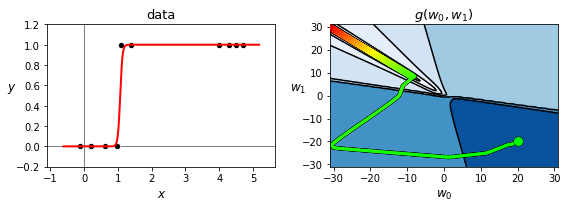

```python
# create instance of logisic regression demo and load in data, cost function, and descent history
demo2 = superlearn.classification_2d_demos_entropy.Visualizer(data,sigmoid_least_squares)

# create a static figure illustrating gradient descent steps
demo2.static_fig(w_hist,num_contours = 25,viewmax = 31)
```

# Exercise 6.2. Show the equivalence of the Log Error and Cross Entropy point-wise cost

Consider the following cases:

**Case 1.** $y_{p}=1$

Plugging $y_{p}=1$ into

$$-{y}_{p}^{\,}\mbox{log}\,\sigma\left(\mathring{\mathbf{x}}_{p}^{T}\mathbf{w}\right)-(1-{y}_{p}^{\,})\mbox{log}\left(1-\sigma\left(\mathring{\mathbf{x}}_{p}^{T}\mathbf{w}\right)\right)$$

gives

$$-\mbox{log}\,\sigma\left(\mathring{\mathbf{x}}_{p}^{T}\mathbf{w}\right)$$

**Case 2.** $y_{p}=0$

Plugging $y_{p}=0$ into

$$-{y}_{p}^{\,}\mbox{log}\,\sigma\left(\mathring{\mathbf{x}}_{p}^{T}\mathbf{w}\right)-(1-{y}_{p}^{\,})\mbox{log}\left(1-\sigma\left(\mathring{\mathbf{x}}_{p}^{T}\mathbf{w}\right)\right)$$

gives

$$-\mbox{log}\left(1-\sigma\left(\mathring{\mathbf{x}}_{p}^{T}\mathbf{w}\right)\right)$$

# Exercise 6.3. Implementing the Cross Entropy cost

```python
# compute linear combination of input point
def model(x,w):
    a = w[0] + np.dot(x.T,w[1:])
    return a.T
```

We can then implement the Cross Entropy cost function by e.g., implementing the Log Loss error and employing efficient and compact `numpy` operations (see the general discussion in Section 3.1.3) as

```python
# define sigmoid function
def sigmoid(t):
    return 1/(1 + np.exp(-t))

# the convex cross-entropy cost function
def cross_entropy(w):
    # compute sigmoid of model
    a = sigmoid(model(x,w))

    # compute cost of label 0 points
    ind = np.argwhere(y == 0)[:,1]
    cost = -np.sum(np.log(1 - a[:,ind]))

    # add cost on label 1 points
    ind = np.argwhere(y==1)[:,1]
    cost -= np.sum(np.log(a[:,ind]))

    # compute cross-entropy
    return cost/y.size
```

```python
# This code cell will not be shown in the HTML version of this notebook
# take input/output pairs from data
x = data[:-1,:]
y = data[-1:,:]

# run gradient descent to minimize the softmax cost
g = cross_entropy; w = np.array([3.0,3.0])[:,np.newaxis]; max_its = 100; alpha_choice = 10**(0);
weight_history,cost_history = optimizers.gradient_descent(g,alpha_choice,max_its,w)
```

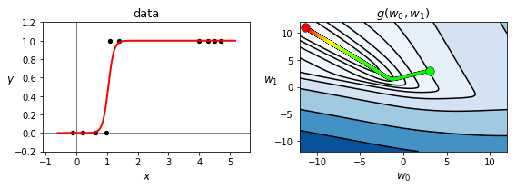

```python
# run gradient descent to minimize the softmax cost
g = cross_entropy; w = np.array([3.0,3.0])[:,np.newaxis]; max_its = 2000; alpha_choice = 1;
weight_history,cost_history = optimizers.gradient_descent(g,alpha_choice,max_its,w)

# create a static figure illustrating gradient descent steps
animator = superlearn.classification_2d_demos_entropy.Visualizer(data,cross_entropy)
animator.static_fig(weight_history,num_contours = 25,viewmax = 12)
```

# Exercise 6.4. Compute the Lipschitz constant of the Cross Entropy cost

Building on the analysis shown in the Endnotes of this Chapter showing that the cross-entropy cost is convex, we can likewise compute its largest possible eigenvalue by noting that the largest value $\sigma_p$ (defined previously) can take is $\frac{1}{4}$

\begin{equation} \sigma_k \leq \frac{1}{4} \end{equation}

Thus the largest value the \emph{Rayleigh quotient} can take is bounded above for any $\mathbf{z}$ as

\begin{equation} \mathbf{z}^T \nabla^2 g\left(\mathbf{w}\right) \mathbf{z}^{\,} \leq \frac{1}{4P}\mathbf{z}^T \left(\sum_{p=1}^{P}\mathring{\mathbf{x}}_p^{\,}\mathring{\mathbf{x}}_p^T \right) \mathbf{z}^{\,} \end{equation}

# Exercise 6.5. Confirm gradient and Hessian calculations

The Cross Entropy cost function is given as $$g(\mathbf{w})=−\frac{1}{P}\sum_{p=1}^{P} y_p \text{ log } \sigma \left(\mathring{\mathbf{x}}_p^T \mathbf{w}\right) + (1−y_p) \text{ log} \left(1-\sigma \left(\mathring{\mathbf{x}}_p^T \mathbf{w}\right) \right)$$

First, let us focus on the $p$th summand

$$g_p(\mathbf{w})= y_p \text{ log } \sigma \left(\mathring{\mathbf{x}}_p^T \mathbf{w}\right) + (1−y_p) \text{ log} \left(1-\sigma \left(\mathring{\mathbf{x}}_p^T \mathbf{w}\right) \right)$$

and compute its partial derivative with respect to the $j$th entry in $\mathbf{w}$, as

$$\frac{\partial g_p}{\partial w_j} = y_p \, x_{p,j}\frac{\sigma \left(\mathring{\mathbf{x}}_p^T \mathbf{w}\right)\left(1-\sigma \left(\mathring{\mathbf{x}}_p^T \mathbf{w}\right) \right) }{\sigma \left(\mathring{\mathbf{x}}_p^T \mathbf{w}\right) } - (1−y_p)\,x_{p,j}\frac{\sigma \left(\mathring{\mathbf{x}}_p^T \mathbf{w}\right)\left(1-\sigma \left(\mathring{\mathbf{x}}_p^T \mathbf{w}\right) \right) }{1-\sigma \left(\mathring{\mathbf{x}}_p^T \mathbf{w}\right) }$$

where we have used the fact that $\frac{\text{d}}{\text{d} w}\sigma = \sigma(w)\left(1-\sigma (w)\right)$.

Simplifying gives

$$\frac{\partial g_p}{\partial w_j} = \left(y_p - \sigma \left(\mathring{\mathbf{x}}_p^T \mathbf{w}\right) \right) x_{p,j}$$

Forming the full gradient vector we have

$$\nabla g_p(\mathbf{w})= \left(y_p - \sigma \left(\mathring{\mathbf{x}}_p^T \mathbf{w}\right) \right) \mathring{\mathbf{x}}_p$$

Taking the sum over all datapoints we have the final form of the gradient as

$$\nabla g(\mathbf{w})=−\frac{1}{P}\sum_{p=1}^{P} \left(y_p - \sigma \left(\mathring{\mathbf{x}}_p^T \mathbf{w}\right) \right) \mathring{\mathbf{x}}_p$$

To compute the $(i,j)$th entry in the Hessian matrix, we take the partial derivative with respect to $w_i$ of $\frac{\partial g_p}{\partial w_j}$ (whose form is already computed above), as

$$\frac{\partial}{\partial w_i}\frac{\partial g_p}{\partial w_j} = \frac{\partial}{\partial w_i}\left(y_p - \sigma \left(\mathring{\mathbf{x}}_p^T \mathbf{w}\right) \right) x_{p,j} = -\sigma \left(\mathring{\mathbf{x}}_p^T \mathbf{w}\right)\left(1-\sigma \left(\mathring{\mathbf{x}}_p^T \mathbf{w}\right) \right) x_{p,i}\,x_{p,j}$$

Taking the sum over all datapoints, we can write the final Hessian matrix as a sum of outer-product matrices of the form

$$\nabla^{2} g(\mathbf{w})=−\frac{1}{P}\sum_{p=1}^{P} -\sigma \left(\mathring{\mathbf{x}}_p^T \mathbf{w}\right)\left(1-\sigma \left(\mathring{\mathbf{x}}_p^T \mathbf{w}\right) \right) \mathring{\mathbf{x}}_p\,\mathring{\mathbf{x}}_p^T \\ = \frac{1}{P}\sum_{p=1}^{P} \sigma \left(\mathring{\mathbf{x}}_p^T \mathbf{w}\right)\left(1-\sigma \left(\mathring{\mathbf{x}}_p^T \mathbf{w}\right) \right) \mathring{\mathbf{x}}_p\,\mathring{\mathbf{x}}_p^T$$

# Exercise 6.6. Show the equivalence of the Log Error and Softmax point-wise cost

Consider the following cases:

**Case 1.** $y_{p}=+1$

Plugging $y_{p}=+1$ into

$$ \mbox{log}\left(1+e^{-y_p \mathring{\mathbf{x}}_{p}^{T}\mathbf{w}}\right) $$

we have

$$ \mbox{log}\left(1+e^{-y_p \mathring{\mathbf{x}}_{p}^{T}\mathbf{w}}\right) = \mbox{log}\left(1+e^{- \mathring{\mathbf{x}}_{p}^{T}\mathbf{w}}\right) = -\mbox{log}\left(\frac{1}{1+e^{- \mathring{\mathbf{x}}_{p}^{T}\mathbf{w}}}\right)= -\mbox{log}\, \sigma\left(\mathring{\mathbf{x}}_{p}^{T}\mathbf{w}\right) $$

**Case 2.** $y_{p}=-1$

Plugging $y_{p}=-1$ into

$$ \mbox{log}\left(1+e^{-y_p \mathring{\mathbf{x}}_{p}^{T}\mathbf{w}}\right) $$

we have

$$ \mbox{log}\left(1+e^{-y_p \mathring{\mathbf{x}}_{p}^{T}\mathbf{w}}\right) = \mbox{log}\left(1+e^{\mathring{\mathbf{x}}_{p}^{T}\mathbf{w}}\right) = -\mbox{log}\left(\frac{1}{1+e^{ \mathring{\mathbf{x}}_{p}^{T}\mathbf{w}}}\right)= -\mbox{log}\, \sigma\left(-\mathring{\mathbf{x}}_{p}^{T}\mathbf{w}\right) $$

# Exercise 6.7. Implementing the Softmax cost

```python
# compute linear combination of input point
def model(x,w):
    a = w[0] + np.dot(x.T,w[1:])
    return a.T
```

```python
# the convex softmax cost function
def softmax(w):
    cost = np.sum(np.log(1 + np.exp(-y*model(x,w))))
    return cost/float(np.size(y))
```

```python
# load in data
csvname = datapath + '2d_classification_data_v1.csv'
data = np.loadtxt(csvname,delimiter = ',')

# take input/output pairs from data
x = data[:-1,:]
y = data[-1:,:]

# run gradient descent to minimize the softmax cost
g = softmax; w = np.array([3.0,3.0])[:,np.newaxis]; max_its = 100; alpha_choice = 1;
weight_history,cost_history = optimizers.gradient_descent(g,alpha_choice,max_its,w)
```

Below we show the result of running gradient descent with the same initial point and fixed steplength parameter for $2000$ iterations, which results in a better fit.

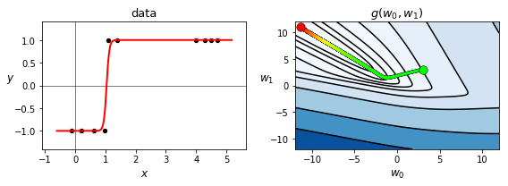

```python
# run gradient descent to minimize the softmax cost
g = softmax; w = np.array([3.0,3.0])[:,np.newaxis]; max_its = 2000; alpha_choice = 1;
weight_history,cost_history = optimizers.gradient_descent(g,alpha_choice,max_its,w)

# create a static figure illustrating gradient descent steps
animator = superlearn.classification_2d_demos.Visualizer(data,g)
animator.static_fig(weight_history,num_contours = 25,viewmax = 12)
```

# Exercise 6.8. Implementing the Log Error version of Softmax

```python
# define sigmoid function
def sigmoid(t):
    return 1/(1 + np.exp(-t))

# the convex cross-entropy cost function
def softmax(w):
    # compute sigmoid of model
    a = sigmoid(model(x,w))

    # compute cost of label 0 points
    ind = np.argwhere(y == -1)[:,1]
    cost = -np.sum(np.log(1 - a[:,ind]))

    # add cost on label 1 points
    ind = np.argwhere(y==+1)[:,1]
    cost -= np.sum(np.log(a[:,ind]))

    # compute cross-entropy
    return cost/y.size
```

```python
# load in dataset
data = np.loadtxt(datapath + '3d_classification_data_v0.csv',delimiter = ',')

# create instance of linear regression demo, used below and in the next examples
demo = superlearn.classification_3d_demos.Visualizer(data)
```

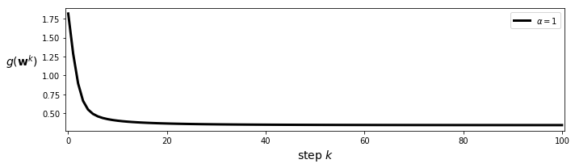

```python
# get input/output pairs
x = data[:-1,:]
y = data[-1:,:]

# run gradient descent to minimize the softmax cost
g = softmax; w = np.random.randn(3,1); max_its = 100; alpha_choice = 1;
weight_history,cost_history = optimizers.gradient_descent(g,alpha_choice,max_its,w)

# plot the cost function history for a given run
static_plotter.plot_cost_histories([cost_history],start = 0,points = False,labels = [r'$\alpha = 1$'])
```

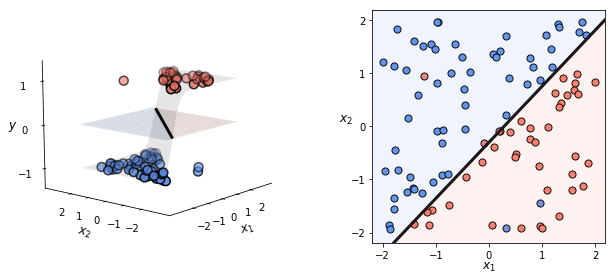

```python
# create instance of 3d demos
demo = superlearn.classification_3d_demos.Visualizer(data)

# draw the final results
demo.static_fig(weight_history[-1],view = [15,-140])
```

# Exercise 6.9. Using gradient descent to minimize the Perceptron cost

```python
data = np.loadtxt(datapath + '3d_classification_data_v0.csv',delimiter = ',')
x = data[:-1,:]
y = data[-1:,:]
```

```python
# compute linear combination of input points
def model(x,w):
    a = w[0] + np.dot(x.T,w[1:])
    return a.T

# an implementation of the perceptron cost
def perceptron(w):
    # compute the least squares cost
    cost = np.sum(np.maximum(0,-y*model(x,w)))
    return cost/float(np.size(y))
```

```python
# setup optimizer input (besides cost)
alpha = 10**(-1)
max_its = 50
w = 0.1*np.random.randn(2+1,1)

# run gradient descent to minimize the Least Squares cost for linear regression
g = perceptron;
weight_history_1,cost_history_1 = optimizers.gradient_descent(g,alpha,max_its,w)
alpha = 10**(-2)
weight_history_2,cost_history_2 = optimizers.gradient_descent(g,alpha,max_its,w)
```

```python
### cost functions ###
def counting_cost(w,x,y):
    # compute predicted labels
    y_hat = np.sign(model(x,w))

    # compare to true labels
    ind = np.argwhere(y != y_hat)
    ind = [v[1] for v in ind]

    cost = np.sum(len(ind))
    return cost
```

```python
count_history_1 = [counting_cost(v,x,y) for v in weight_history_1]
count_history_2 = [counting_cost(v,x,y) for v in weight_history_2]
```

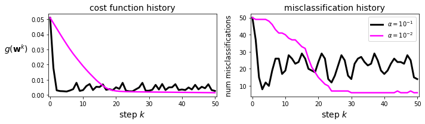

```python
# plot history
classif_plotter = superlearn.classification_static_plotter.Visualizer()

cost_histories = [cost_history_1,cost_history_2]
count_histories = [count_history_1,count_history_2]
classif_plotter.plot_cost_histories(cost_histories,count_histories,start = 0,points = False,labels = [r'$\alpha = 10^{-1}$',r'$\alpha = 10^{-2}$'])
```

# Exercise 6.10. The Perceptron cost is convex

**a)** Defining the constant vector $\mathbf{c}=-y_{p}\mathring{\mathbf{x}}_{p}$, we can write each summand as $h\left(\mathbf{{\mathbf{w}}}\right)=\mbox{max}\left(0,\,\mathbf{c}^{T}{\mathbf{w}}\right)$. According to the zeroth order definition of convexity, $h$ is convex if\noindent

\begin{equation} h\left(\lambda\mathbf{{\mathbf{w}}}_{1}+\left(1-\lambda\right)\mathbf{{\mathbf{w}}}_{2}\right)\leq\lambda h\left(\mathbf{{\mathbf{w}}}_{1}\right)+\left(1-\lambda\right)h\left(\mathbf{{\mathbf{w}}}_{2}\right), \end{equation}

for all $0\leq\lambda\leq1$. Using the definition of $h$ we need to show that

\begin{equation} \mbox{max}\left(0,\,\mathbf{c}^{T}\left(\lambda\mathbf{{\mathbf{w}}}_{1}+\left(1-\lambda\right)\mathbf{{\mathbf{w}}}_{2}\right)\right)\leq\lambda\mbox{max}\left(0,\,\mathbf{c}^{T}{\mathbf{w}_{1}}\right)+\left(1-\lambda\right)\mbox{max}\left(0,\,\mathbf{c}^{T}{\mathbf{w}}_{2}\right). \end{equation}

or equivalently

\begin{equation} \mbox{max}\left(0,\,\lambda\mathbf{c}^{T}\mathbf{w}_{1}+\left(1-\lambda\right)\mathbf{c}^{T}\mathbf{w}_{2}\right)\leq\mbox{max}\left(0,\,\lambda\mathbf{c}^{T}\mathbf{w}_{1}\right)+\mbox{max}\left(0,\,\left(1-\lambda\right)\mathbf{c}^{T}\mathbf{w}_{2}\right) \end{equation}

using the fact that $\lambda\mbox{max}\left(0,\,\zeta\right)=\mbox{max}\left(0,\,\lambda\zeta\right)$ when $\lambda$ is nonnegative. Now to see that this does indeed holds, we break it down into four cases:

**Case 1.** $\lambda\mathbf{c}^{T}{\mathbf{w}_{1}}\geq0$ and $\left(1-\lambda\right)\mathbf{c}^{T}{\mathbf{w}}_{2}\geq0$

In this case both sides of the above simplify to $\lambda\mathbf{c}^{T}\mathbf{w}_{1}+\left(1-\lambda\right)\mathbf{c}^{T}\mathbf{w}_{2}$ and we have equality.

**Case 2.** $\lambda\mathbf{c}^{T}\mathbf{w}_{1}<0$ and $\left(1-\lambda\right)\mathbf{c}^{T}\mathbf{w}_{2}<0$

In this case both sides of the above simplify to 0 and we have equality again.

**Case 3.** $\lambda\mathbf{c}^{T}\mathbf{w}_{1}\geq0$ and $\left(1-\lambda\right)\mathbf{c}^{T}\mathbf{w}_{2}<0$

In this case we have

\begin{equation} \mbox{max}\left(0,\,\lambda\mathbf{c}^{T}\mathbf{w}_{1}+\left(1-\lambda\right)\mathbf{c}^{T}\mathbf{w}_{2}\right)\leq\mbox{max}\left(0,\,\lambda\mathbf{c}^{T}\mathbf{w}_{1}\right)\leq\mbox{max}\left(0,\,\lambda\mathbf{c}^{T}\mathbf{w}_{1}\right)+\mbox{max}\left(0,\,\left(1-\lambda\right)\mathbf{c}^{T}\mathbf{w}_{2}\right). \end{equation}

**Case 4.** $\lambda\mathbf{c}^{T}\mathbf{w}_{1}<0$ and $\left(1-\lambda\right)\mathbf{c}^{T}\mathbf{w}_{2}\geq0$

In this case we have

\begin{equation} \mbox{max}\left(0,\,\lambda\mathbf{c}^{T}\mathbf{w}_{1}+\left(1-\lambda\right)\mathbf{c}^{T}\mathbf{w}_{2}\right)\leq\mbox{max}\left(0,\,\left(1-\lambda\right)\mathbf{c}^{T}\mathbf{w}_{2}\right)\leq\mbox{max}\left(0,\,\lambda\mathbf{c}^{T}\mathbf{w}_{1}\right)+\mbox{max}\left(0,\,\left(1-\lambda\right)\mathbf{c}^{T}\mathbf{w}_{2}\right). \end{equation}

# Exercise 6.11. The Softmax cost is convex

The Hessian for the logistic regression cost $g$ is given by\noindent \begin{equation} \nabla^{2}g\left(\mathbf{w}\right)=\underset{p=1}{\overset{P}{\sum}}\sigma\left(-y_{p}^{\,}\mathbf{\mathbf{\mathring{x}}}_{p}^{T}\mathbf{\mathbf{{w}}}\right)\left(1-\sigma\left(-y_{p}^{\,}\mathbf{\mathbf{\mathring{x}}}_{p}^{T}\mathbf{\mathbf{{w}}}\right)\right)\mathbf{\mathbf{\mathring{x}}}_{p}^{\,}\mathbf{\mathbf{\mathring{x}}}_{p}^{T}. \end{equation}

To prove $g$ is convex, we use the second order definition of convexity and show $\nabla^{2}g\left(\mathbf{{w}}\right)$ is positive semidefinite by forming\noindent

\begin{equation} \psi\left(\mathbf{z}\right)=\mathbf{z}^{T}\nabla^{2}g\left(\mathbf{{w}}\right)\mathbf{z}=\mathbf{z}^{T}\left[\underset{p=1}{\overset{P}{\sum}}\sigma\left(-y_{p}^{\,}\mathbf{\mathbf{\mathring{x}}}_{p}^{T}\mathbf{\mathbf{{w}}}\right)\left(1-\sigma\left(-y_{p}^{\,}\mathbf{\mathbf{\mathring{x}}}_{p}^{T}\mathbf{\mathbf{{w}}}\right)\right)\mathbf{\mathbf{\mathring{x}}}_{p}^{\,}\mathbf{\mathbf{\mathring{x}}}_{p}^{T}\right]\mathbf{z} \end{equation}

\begin{equation} =\underset{p=1}{\overset{P}{\sum}}\delta_{p}\left(\mathbf{\mathbf{\mathring{x}}}_{p}^{T}\mathbf{z}\right)^{2}, \end{equation}

where $\delta_{p}=\sigma\left(-y_{p}^{\,}\mathbf{\mathbf{\mathring{x}}}_{p}^{T}\mathbf{\mathbf{{w}}}\right)\left(1-\sigma\left(-y_{p}^{\,}\mathbf{\mathbf{\mathring{x}}}_{p}^{T}\mathbf{\mathbf{{w}}}\right)\right)$. Now note that since $0\leq\sigma\left(\zeta\right)\leq1$ we have that $\delta_{p}\geq0$, and therefore \noindent \begin{equation} \mathbf{z}^{T}\nabla^{2}g\left(\mathbf{{w}}\right)\mathbf{z}=\underset{p=1}{\overset{P}{\sum}}\delta_{p}\left(\mathbf{\mathbf{\mathring{x}}}_{p}^{T}\mathbf{z}\right)^{2}\geq0. \end{equation}

# Exercise 6.12. The regularized Softmax

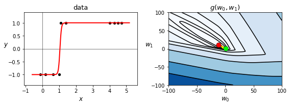

```python
# This code cell will not be shown in the HTML version of this notebook
### define softmax cost ###
# compute linear combination of input point
def model(x,w):
    a = w[0] + np.dot(x.T,w[1:])
    return a.T

# the convex softmax cost function
lam = 2*10**(-3)
def softmax(w):
    # compute cost value
    cost = np.sum(np.log(1 + np.exp(-y*model(x,w))))

    # add regularizer
    cost += lam*np.sum(w[1:]**2)
    return cost/float(np.size(y))

# load in dataset
data = np.loadtxt(datapath + '2d_classification_data_v1.csv',delimiter = ',')

# get input/output pairs
x = data[:-1,:]
y = data[-1:,:]

# run gradient descent to minimize the softmax cost
g = softmax; w = np.ones((2,1)); max_its = 5;
weight_history,cost_history = optimizers.newtons_method(g,max_its,w,epsilon = 10**(-7))

# create instance of logisic regression demo and load in data, cost function, and descent history
animator = superlearn.classification_2d_demos.Visualizer(data,softmax)

# create a static figure illustrating gradient descent steps
animator.static_fig(weight_history,num_contours = 25,viewmax = 100)
```

# Exercise 6.13. Compare the efficacy of two-class cost functions I

```python
# data input
csvname = datapath + 'breast_cancer_data.csv'
data1 = np.loadtxt(csvname,delimiter = ',')

# get input and output of dataset
x = data1[:-1,:]
y = data1[-1:,:]
```

```python
print (x.shape)
```

```
(8, 699)
```

Here `y` contains the labels for each point.

```python
print (y.shape)
```

```
(1, 699)
```

We will use the gradient descent module defined in Chapter 3 here as a backend file.

Below we implement each of the required cost functions.

```python
# compute linear combination of input points
def model(x,w):
    a = w[0] + np.dot(x.T,w[1:])
    return a.T
```

```python
# an implementation of the perceptron cost
def perceptron(w):
    # compute the least squares cost
    cost = np.sum(np.maximum(0,-y*model(x,w)))
    return cost/float(np.size(y))
```

```python
# an implementation of the softmax cost
def softmax(w):
    # compute the least squares cost
    cost = np.sum(np.log(1 + np.exp(-y*model(x,w))))
    return cost/float(np.size(y))
```

Now we run gradient descent to minimize each over the first (breast cancer dataset), plotting the resulting cost function and misclassification histories.

```python
# setup data
N = x.shape[0]

# setup optimizer input (besides cost)
alpha = 10**(-1)
max_its = 1000
w = 0.1*np.random.randn(N+1,1)

# run gradient descent to minimize the Least Squares cost for linear regression
g = perceptron;
weight_history_1,cost_history_1 = optimizers.gradient_descent(g,alpha,max_its,w)

alpha = 10**(0)
g = softmax;
weight_history_2,cost_history_2 = optimizers.gradient_descent(g,alpha,max_its,w)
```

Construct misclassification counter.

```python
### cost functions ###
def counting_cost(w,x,y):
    # compute predicted labels
    y_hat = np.sign(model(x,w))

    # compare to true labels
    ind = np.argwhere(y != y_hat)
    ind = [v[1] for v in ind]

    cost = np.sum(len(ind))
    return cost
```

Create misclassification history for each run.

```python
count_history_1 = [counting_cost(v,x,y) for v in weight_history_1]
count_history_2 = [counting_cost(v,x,y) for v in weight_history_2]
```

Plot cost and count histories.

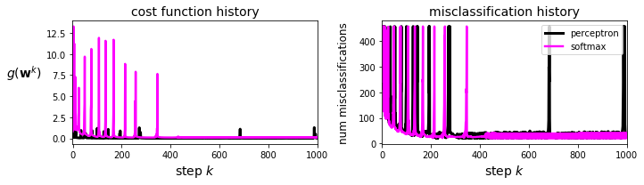

```python
# plot history
classif_plotter = superlearn.classification_static_plotter.Visualizer()

cost_histories = [cost_history_1,cost_history_2]
count_histories = [count_history_1,count_history_2]
classif_plotter.plot_cost_histories(cost_histories,count_histories,start = 0,points = False,labels = ['perceptron','softmax'])
```

```python
best_percept = np.min(count_history_1)
best_soft = np.min(count_history_2)

print ('the smallest number of misclassifications provided by minimizing the perceptron ' + str(best_percept))
print ('the smallest number of misclassifications provided by minimizing the softmax ' + str(best_soft))
```

```
the smallest number of misclassifications provided by minimizing the perceptron 20
the smallest number of misclassifications provided by minimizing the softmax 21
```

# Exercise 6.14. Compare the efficacy of two-class cost functions II

```python
# standard normalization function - with nan checker / filler in-er
def standard_normalizer(x):
    # compute the mean and standard deviation of the input
    x_means = np.nanmean(x,axis = 1)[:,np.newaxis]
    x_stds = np.nanstd(x,axis = 1)[:,np.newaxis]

    # check to make sure thta x_stds > small threshold, for those not
    # divide by 1 instead of original standard deviation
    ind = np.argwhere(x_stds < 10**(-2))
    if len(ind) > 0:
        ind = [v[0] for v in ind]
        adjust = np.zeros((x_stds.shape))
        adjust[ind] = 1.0
        x_stds += adjust

    # fill in any nan values with means
    ind = np.argwhere(np.isnan(x) == True)
    for i in ind:
        x[i[0],i[1]] = x_means[i[0]]

    # create standard normalizer function
    normalizer = lambda data: (data - x_means)/x_stds

    # create inverse standard normalizer
    inverse_normalizer = lambda data: data*x_stds + x_means

    # return normalizer
    return normalizer,inverse_normalizer
```

Below we load in a spam email dataset - [a description of which you can find here](https://archive.ics.uci.edu/ml/datasets/Spambase). The input datapoints are stacked *column-wise* in this dataset, with the final row being the label of each point.

```python
# data input
csvname = datapath + 'spambase_data.csv'
data = np.loadtxt(csvname,delimiter = ',')

# get input and output of dataset
x = data[:-1,:]
y = data[-1:,:]
```

```python
ind0 = np.argwhere(y==-1)
ind1 = np.argwhere(y==+1)
print(len(ind0),len(ind1))
```

```
2788 1813
```

Standard normalize input.

```python
normalizer,inverse_normalizer = standard_normalizer(x)
x = normalizer(x)
```

```python
# setup data
N = x.shape[0]

# setup optimizer input (besides cost)
alpha = 10**(-1)
max_its = 1000
w = 0.1*np.random.randn(N+1,1)

# run gradient descent to minimize the Least Squares cost for linear regression
g = perceptron;
weight_history_1,cost_history_1 = optimizers.gradient_descent(g,alpha,max_its,w)

alpha = 10**(1)
g = softmax;
weight_history_2,cost_history_2 = optimizers.gradient_descent(g,alpha,max_its,w)
```

```python
### cost functions ###
def counting_cost(w,x,y):
    # compute predicted labels
    y_hat = np.sign(model(x,w))

    # compare to true labels
    ind = np.argwhere(y != y_hat)
    ind = [v[1] for v in ind]

    cost = np.sum(len(ind))
    return cost

count_history_1 = [counting_cost(v,x,y) for v in weight_history_1]
count_history_2 = [counting_cost(v,x,y) for v in weight_history_2]
```

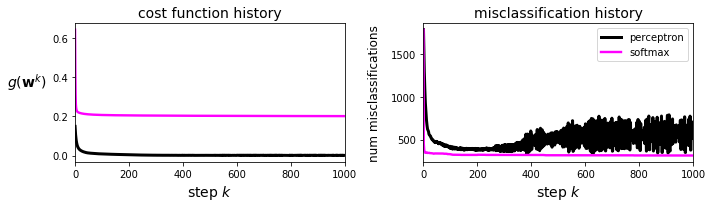

```python
# plot history
classif_plotter = superlearn.classification_static_plotter.Visualizer()

cost_histories = [cost_history_1,cost_history_2]
count_histories = [count_history_1,count_history_2]
classif_plotter.plot_cost_histories(cost_histories,count_histories,start = 0,points = False,labels = ['perceptron','softmax'])
```

```python
best_percept = np.min(count_history_1)
best_soft = np.min(count_history_2)

print ('the smallest number of misclassifications provided by minimizing the perceptron ' + str(best_percept))
print ('the smallest number of misclassifications provided by minimizing the softmax ' + str(best_soft))
```

```
the smallest number of misclassifications provided by minimizing the perceptron 339
the smallest number of misclassifications provided by minimizing the softmax 315
```

```python
(1 - 315/4601)
```

```
0.9315366224733753
```

```python
import copy
def confusion_matrix(y,y_hat):
    labels = np.unique(y)
    num_labels = len(labels)
    c = np.zeros((num_labels,num_labels))
    inds = []
    inds_hat = []
    for l in labels:
        ind0 = np.argwhere(y==l)
        if len(ind0) > 0:
            ind0 = [v[1] for v in ind0]
        inds.append(ind0)
        ind1 = np.argwhere(y_hat==l)
        if len(ind1) > 0:
            ind1 = [v[1] for v in ind1]
        inds_hat.append(ind1)

    for i in range(num_labels):
        ind0 = set(inds[i])
        for j in range(num_labels):
            ind1 = set(inds_hat[j])
            misclass = len(ind1.intersection(ind0))
            c[i,j] = misclass
    return c
```

```python
ind_best = np.argmin(count_history_2)
w_best = weight_history_2[ind_best]
y_hat = np.sign(model(x,w_best))
c = confusion_matrix(y,y_hat)
print(c)
```

```
[[2664.  124.]
 [ 191. 1622.]]
```

# Exercise 6.15. Credit check

```python
# load in dataset
csvname = datapath + 'credit_dataset.csv'
data = np.loadtxt(csvname,delimiter = ',')
x = data[:-1,:]
y = data[-1:,:]
```

```python
ind0 = np.argwhere(y==-1)
ind1 = np.argwhere(y==+1)
print(len(ind0),len(ind1))
```

```
300 700
```

Standard normalize input.

```python
normalizer,inverse_normalizer = standard_normalizer(x)
x = normalizer(x)
```

```python
# setup data
N = x.shape[0]

# setup optimizer input (besides cost)
alpha = 10**(-1)
max_its = 1000
w = 0.1*np.random.randn(N+1,1)

# run gradient descent to minimize the Least Squares cost for linear regression
g = perceptron;
weight_history_1,cost_history_1 = optimizers.gradient_descent(g,alpha,max_its,w)
```

```python
### cost functions ###
def counting_cost(w,x,y):
    # compute predicted labels
    y_hat = np.sign(model(x,w))

    # compare to true labels
    ind = np.argwhere(y != y_hat)
    ind = [v[1] for v in ind]

    cost = np.sum(len(ind))
    return cost

count_history_1 = [counting_cost(v,x,y) for v in weight_history_1]
count_history_2 = [counting_cost(v,x,y) for v in weight_history_2]
```

[figure not shown]

```python
# plot history
classif_plotter = superlearn.classification_static_plotter.Visualizer()

cost_histories = [cost_history_1,cost_history_2]
count_histories = [count_history_1,count_history_2]
classif_plotter.plot_cost_histories(cost_histories,count_histories,start = 0,points = False,labels = ['perceptron','softmax'])
```

```python
best_percept = np.min(count_history_1)
best_percept_acc = (1 - best_percept/y.size)

print ('the smallest number of misclassifications provided by minimizing the perceptron ' + str(best_percept))
print ('best acc by minimizing the perceptron ' + str(best_percept_acc))
```

[output not shown]

```python
ind_best = np.argmin(count_history_1)
w_best = weight_history_2[ind_best]
y_hat = np.sign(model(x,w_best))
c = confusion_matrix(y,y_hat)
print(c)
```

```
[[285.  15.]
 [466. 234.]]
```

```python
y.size
```

```
1000
```

# Exercise 6.16. Weighted classification and balanced accuracy

```python
def balanced_accuracy(w,x,y):
    # make predictions
    y_hat = np.sign(model(x,w))
    print(y_hat.shape)

    # press predictions against real results
    ind0 = np.argwhere(y == -1)
    ind0 = [v[1] for v in ind0]
    num0 = len(ind0)

    ind = np.argwhere(np.abs(y[:,ind0] - y_hat[:,ind0]) > 0)
    cost0 = len(ind)

    ind1 = np.argwhere(y == +1)
    ind1 = [v[1] for v in ind1]
    num1 = len(ind1)
    ind = np.argwhere(np.abs(y[:,ind1] - y_hat[:,ind1]) > 0)
    cost1 = len(ind)

    # compute accuracies
    acc0 = 1 - cost0/num0
    acc1 = 1 - cost1/num1
    return (acc0 + acc1)/2
```

```python
# data input
csvname = datapath + '3d_classification_data_v2_mbalanced.csv'
data1 = np.loadtxt(csvname,delimiter = ',')

# get input and output of dataset
x = data1[:-1,:]
y = data1[-1:,:]
```

```python
ind0 = np.argwhere(y==-1)
ind1 = np.argwhere(y==+1)
print(len(ind0),len(ind1))
```

```
50 5
```

```python
betas = np.array([1.0,5.0])

# define sigmoid function
def sigmoid(t):
    return 1/(1 + np.exp(-t))

# the convex cross-entropy cost function
def weighted_softmax(w,betas):
    # compute sigmoid of model
    a = sigmoid(model(x,w))

    # compute cost of label 0 points
    ind = np.argwhere(y == -1)[:,1]
    cost = -betas[0]*np.sum(np.log(1 - a[:,ind]))

    # add cost on label 1 points
    ind = np.argwhere(y==+1)[:,1]
    cost -= betas[1]*np.sum(np.log(a[:,ind]))

    # compute cross-entropy
    return cost/y.size
```

```python
betas = np.array([1.0,1.0])
softmax = lambda w,betas = betas: weighted_softmax(w,betas)
```

```python
# setup data
N = x.shape[0]

# setup optimizer input (besides cost)
max_its = 5
w = 0.1*np.random.randn(N+1,1)

# run gradient descent to minimize the Least Squares cost for linear regression
g = softmax;
weight_history_1,cost_history_1 = optimizers.newtons_method(g,max_its,w)
```

```python
### cost functions ###
def counting_cost(w,x,y):
    # compute predicted labels
    y_hat = np.sign(model(x,w))

    # compare to true labels
    ind = np.argwhere(y != y_hat)
    ind = [v[1] for v in ind]

    cost = np.sum(len(ind))
    return cost

count_history_1 = [counting_cost(v,x,y) for v in weight_history_1]
```

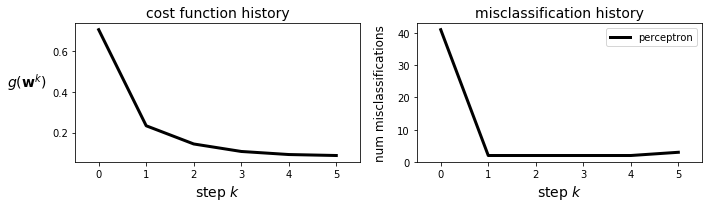

```python
# plot history
classif_plotter = superlearn.classification_static_plotter.Visualizer()

cost_histories = [cost_history_1]
count_histories = [count_history_1]
classif_plotter.plot_cost_histories(cost_histories,count_histories,start = 0,points = False,labels = ['perceptron','softmax'])
```

```python
w_best = weight_history_1[-1]
best_soft_count = count_history_1[-1]
best_soft_acc = (1 - best_soft_count/y.size)
best_balanced = balanced_accuracy(w_best,x,y)

print ('the smallest number of misclassifications provided by minimizing the softmxa ' + str(best_soft_count))
print ('best acc by minimizing the softmax ' + str(best_soft_acc))
print ('best balanced acc by minimizing the softmax ' + str(best_balanced))
```

```
(1, 55)
the smallest number of misclassifications provided by minimizing the softmxa 3
best acc by minimizing the softmax 0.9454545454545454
best balanced acc by minimizing the softmax 0.79
```

$\beta = 5$

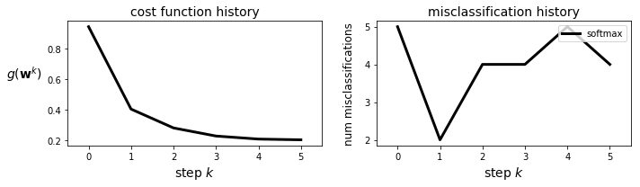

```
(1, 55)
the smallest number of misclassifications provided by minimizing the softmxa 4
best acc by minimizing the softmax 0.9272727272727272
best balanced acc by minimizing the softmax 0.87
```

```python
# setup data
N = x.shape[0]

# setup optimizer input (besides cost)
max_its = 5
w = 0.1*np.random.randn(N+1,1)

# run gradient descent to minimize the Least Squares cost for linear regression
betas = np.array([1.0,5.0])
softmax = lambda w,betas = betas: weighted_softmax(w,betas)
g = softmax;
weight_history_2,cost_history_2 = optimizers.newtons_method(g,max_its,w)
count_history_2 = [counting_cost(v,x,y) for v in weight_history_2]

# plot history
classif_plotter = superlearn.classification_static_plotter.Visualizer()

cost_histories = [cost_history_2]
count_histories = [count_history_2]
classif_plotter.plot_cost_histories(cost_histories,count_histories,start = 0,points = False,labels = ['softmax'])

w_best = weight_history_2[-1]
best_soft_count = count_history_2[-1]
best_soft_acc = (1 - best_soft_count/y.size)
best_balanced = balanced_accuracy(w_best,x,y)

print ('the smallest number of misclassifications provided by minimizing the softmxa ' + str(best_soft_count))
print ('best acc by minimizing the softmax ' + str(best_soft_acc))
print ('best balanced acc by minimizing the softmax ' + str(best_balanced))
```

$\beta = 10$

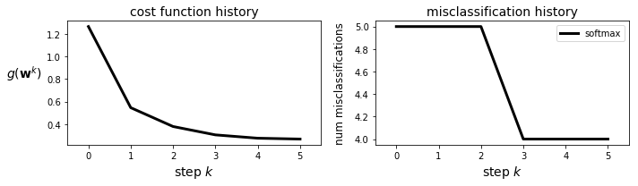

```
(1, 55)
the smallest number of misclassifications provided by minimizing the softmxa 4
best acc by minimizing the softmax 0.9272727272727272
best balanced acc by minimizing the softmax 0.96
```

```python
# setup data
N = x.shape[0]

# setup optimizer input (besides cost)
max_its = 5
w = 0.1*np.random.randn(N+1,1)

# run gradient descent to minimize the Least Squares cost for linear regression
betas = np.array([1.0,10.0])
softmax = lambda w,betas = betas: weighted_softmax(w,betas)
g = softmax;
weight_history_3,cost_history_3 = optimizers.newtons_method(g,max_its,w)
count_history_3 = [counting_cost(v,x,y) for v in weight_history_3]

# plot history
classif_plotter = superlearn.classification_static_plotter.Visualizer()

cost_histories = [cost_history_3]
count_histories = [count_history_3]
classif_plotter.plot_cost_histories(cost_histories,count_histories,start = 0,points = False,labels = ['softmax'])

w_best = weight_history_3[-1]
best_soft_count = count_history_3[-1]
best_soft_acc = (1 - best_soft_count/y.size)
best_balanced = balanced_accuracy(w_best,x,y)

print ('the smallest number of misclassifications provided by minimizing the softmxa ' + str(best_soft_count))
print ('best acc by minimizing the softmax ' + str(best_soft_acc))
print ('best balanced acc by minimizing the softmax ' + str(best_balanced))
```